# El tractor agrícola

[figure not shown]

Tractor agrícola

**1. Tipos de tractores**

## 1. Tipos de tractores

Un **tractor agrícola** es una máquina diseñada principalmente para facilitar las labores del campo. Su función principal es **arrastrar o accionar implementos agrícolas**, como arados, sembradoras o pulverizadoras, reduciendo el esfuerzo físico y aumentando la eficiencia. Hay de diversos tipos según veremos en la siguiente actividad.

### Actividad

**a)** Mientras que en Argentina es común usar “hectáreas” para el área de los campos hay otros que usan “acres”. Nos será útil aprenderla ahora para comprender mejor la información sobre tractores que veremos en un video. Completa la siguiente table teniendo en cuenta que: Un acre equivale a 0,4047 hectáreas, aproximadamente.

| Acres | Hectáreas aproximadas |
| --- | --- |
| 1 | 0,40 ha |
| 5 | 2,02 ha |
| 10 | 4,05 ha |
| 50 |  |
| 100 |  |
| 1.000 |  |

**b)** Observa este [video](https://www.youtube.com/watch?v=zIqvauutGSw) y anota al menos 4 tipos de tractores agregando el tamaño del terreno en hectáreas para el que son adecuados y alguna otra característica.

**c)** Completa los espacios con una sola palabra: *Un tractor _____ genera gastos innecesarios de _____, mantenimiento y seguro. Comprar por “orgullo” o “por si acaso” puede _____ una pequeña explotación. La regla de oro antes de elegir un _____ es elegirlo según el _____ de la finca, el trabajo semanal real y el presupuesto.*

**d)** ¿Qué ventaja principal tienen los tractores de orugas sobre los de ruedas?

**2. Partes de un tractor**

## 2. Partes de un tractor

Las partes principales de un tractor tienen que ver con el motor y las partes que permiten que su movimiento llegue a las ruedas y a la toma de fuerza. En la actividad vamos a aprender con más detalle esto.

### Actividad

Observa el [video](https://www.youtube.com/watch?v=ZFAvJ6J-glw) y luego haz un dibujo esquemático de un tractor como el de la figura de abajo poniendo nombre a todas las partes. En la figura faltan algunos nombres.

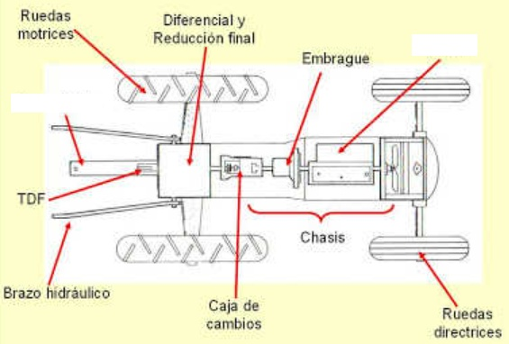

**3. La conducción de un tractor**

## 3. La conducción de un tractor

Manejar maquinaria agrícola pesada como un tractor requiere destrezas muy distintas a las de conducir un coche convencional. A diferencia de los automóviles de uso diario, los tractores están diseñados para trabajos de gran fuerza y precisión en el campo, por lo que su manejo correcto exige aplicar técnicas específicas de mecánica, seguridad y eficiencia energética.

A través de este [vídeo](https://www.youtube.com/watch?v=hixXBe-BtNY) descubriremos principios básicos que aplican los tractoristas profesionales en su día a día.

### Actividad

En base al video que vimos, *“Secretos que SOLO los conductores PRO de tractor conocen”*, responde a las siguientes preguntas sobre los consejos básicos de manejo y seguridad.

1. **Los frenos del tractor:** ¿Por qué los tractores tienen dos pedales de freno independientes y qué ocurre cuando pisas solo uno de ellos?
2. **Las marchas y el arranque:** ¿En qué se diferencia la forma de arrancar un tractor de la de un coche turismo convencional?
3. **El uso del embrague (*clutch*):** ¿Qué error común cometen los conductores principiantes con el pedal del embrague y qué problema causa en el tractor?
4. **Ahorro de combustible:** Si estás realizando un trabajo ligero en el campo, ¿cómo debes combinar las revoluciones del motor y las marchas para no gastar tanto combustible?
5. **El bloqueo del diferencial:** ¿Para qué sirve la palanca del bloqueo del diferencial y por qué **no** se debe dejar activada continuamente?
6. **El sonido del motor:** ¿Por qué es importante que el tractorista aprenda a reconocer el sonido habitual del motor de su tractor?
7. **Conducir en línea recta:** Para trabajar el campo en línea recta sin torcerte ni desviarte, ¿dónde debes fijar la mirada mientras conduces?

**4. Lubricación del tractor agrícola**

## 4. Lubricación del tractor agrícola

Un tractor tiene muchas piezas que se mueven y rozan por lo que es importante que esté bien lubricado. El lubricante además de reducir la fricción y el sobrecalentamiento también ayuda a proteger las piezas contra la corrosión.

**Para lubricar se usa:**

- **Aceites lubricantes:** son líquidos y circulan por el interior de los mecanismos.
- **Grasas lubricantes:** son más espesas y permanecen adheridas a las superficies, especialmente en mecanismos donde el aceite podría escurrirse.

**¿Dónde se utilizan?**

- **Motor:** Puede usarse SAE 15W-40, SAE 10W-30, etc. según las especificaciones del fabricante.
- **Transmisión y diferencial:** Se utiliza aceite para engranajes, por ejemplo SAE 80W-90 pero siempre siguiendo lo que indique el fabricante.
- **Sistema hidráulico:** Utiliza aceite hidráulico. Este aceite además de lubricar permite transmitir fuerza mediante la presión del líquido y se utiliza para levantar implementos y accionar cilindros hidráulicos.
- **Puntos de engrase:** Se utiliza generalmente grasa multipropósito de litio. Se aplica en articulaciones, crucetas, rodamientos y puntos de movimiento indicados por el fabricante. Se introduce mediante una herramienta llamada engrasadora.

### Actividades

**a)** Averiguar y escribir ejemplos de aceites usados en el sistema hidráulico.

**b)** ¿Cuál es el menos viscoso de los aceites que usa una tractor según lo que leíste en esta guá y buscaste en el punto anterior?

**c)** Busca algún video breve sobre los puntos de engrase en el tractor y escribe una lista de esos puntos según aparece en el video. Anota el nombre del video.

**d)** Escribe completa esta frase que resume puntos importantes a tener en cuenta: *La _____ no es solamente agregar aceite. También implica _____ los niveles, revisar posibles pérdidas y cambiar los _____ siguiendo los intervalos de mantenimiento recomendados.* Usa las palabras que mejor te parezca que encajan.